# **Spotify Top 100 Analysis**

Juanrico Alvaro, Mikhael Enrico Setianto, Renaldo Fareza Tambunan

2022-07-13

### Group Members

1. Mikhael Enrico Setianto [702300]
2. Juanrico Alvaro [702301]
3. Renaldo Fareza Tambunan [702314]

## **2. PROJECT REQUIREMENT**

### 2.1 Introduction to the Project

Spotify is the most well-known music streaming app in the world, users can access millions of songs and also many podcasts around the world. Nowadays, Spotify can be found on almost every device, especially among the millennials, because of its multi-platform apps and free to use.

Spotify is free, but for more convenient features the user can subscribe to Spotify Premium which the minimum cost around $10 per month. The features that the user can get as the premium user is the ability to disable ads and also unlimited songs skip. For this project, we are going to use dataset that is provided by Spotify to perform some exploratory data analysis using R language.

### 2.2 Problems Need to be Solved

Spotify provide a dataset of all daily hit charts curated by Spotify that is published on Kaggle website ( [Visit Website](https://kaggle.com) ). The data will contain top 100 song from 2010 until 2019 with .xslx data format and 1000 total records from the past ten years. This dataset is still unprocessed and there is more room to do more exploratory and predictive data analysis.

### 2.3 Data Analysis Specifications

The objective of this system is to read the data in analysis manner with this functionality:

- Get top popular song genre for every 5 year
- Get top popular artist for every 5 year
- Get song that was released outside the chart year range
- Get artist which appeared on the charts maximum number of times
- Show the relationship between music features
- Show the trend of BPM, Energy, Danceability, Live, Acoustic, Speechabilty, Popularity from 2010 to 2019
- Create top genre model and get the best K for the prediction (predict using KNN)

### 2.4 Project Scope

The project will be revolving around descriptive and predictive analysis on Spotify. We are going to use R Language as the programming language and R Studio as the IDE. Later will be delivered as HTML document generated by R Markdown.

## **3. DATA PREPARATION**

We will prepare the data frame through some processes so that the data frame will be ready for prediction and exploratory analysis purposes.

### 3.1 Data Acquiring

We will read the data from kaggle that has been given in csv format using read.csv

```r
df<-read.csv(file = "Spotify_2010_-_2019_Top_100.csv",header = TRUE, sep=",")
head(df,5)
```

```
##                                           title     artist   top.genre
## 1                 STARSTRUKK (feat. Katy Perry)      3OH!3   dance pop
## 2                   My First Kiss (feat. Ke$ha)      3OH!3   dance pop
## 3                               I Need A Dollar Aloe Blacc    pop soul
## 4 Airplanes (feat. Hayley Williams of Paramore)      B.o.B atl hip hop
## 5             Nothin' on You (feat. Bruno Mars)      B.o.B atl hip hop
##   year.released      added bpm nrgy dnce dB live val dur acous spch pop
## 1          2009 2022‑02‑17 140   81   61 -6   23  23 203     0    6  70
## 2          2010 2022‑02‑17 138   89   68 -4   36  83 192     1    8  68
## 3          2010 2022‑02‑17  95   48   84 -7    9  96 243    20    3  72
## 4          2010 2022‑02‑17  93   87   66 -4    4  38 180    11   12  80
## 5          2010 2022‑02‑17 104   85   69 -6    9  74 268    39    5  79
##   top.year artist.type
## 1     2010         Duo
## 2     2010         Duo
## 3     2010        Solo
## 4     2010        Solo
## 5     2010        Solo
```

```r
nrow(df)
```

```
## [1] 1003
```

### 3.2 Data Cleaning

#### *Removing NA value*

Check if there is NA value inside the dataframe.

```r
nrow(which(is.na(df), arr.ind=TRUE))
```

```
## [1] 36
```

There are 36 position that is filled with NA value now we can remove those na value.

```r
df <- na.omit(df)
nrow(df)
```

```
## [1] 1000
```

#### *Changing Date Release data type*

The date format use ASCII value as the hypen. We need to process it by removing a non-alpha numeric using gsub() function and reformat it using as.Date() function. below we will show the class of date release.

```r
df$added<-gsub("[[:punct:]]", "", df$added)
df$added <- as.Date(df[["added"]], "%Y%m%d")
class(df$added)
```

```
## [1] "Date"
```

### 3.3 Data Transformation

#### *Simplify the data frame*

Since we will do some prediction on the song genre it is better to classified the genre into a simpler form

```r
length(unique(df$top.genre))
```

```
## [1] 132
```

```r
genre_dict <- c(
  "dance pop","pop",
  "pop soul","soul",
  "atl hip hop","hip hop",
  "pop rap","rap",
  "big room","house",
  "canadian hip hop","hip hop",
  "disco house","house",
  "romanian house","house",
  'lilith',"indie",
  'detroit hip hop',"hip hop",
  'asian american hip hop',"hip hop",
  'east coast hip hop', "hip hop",
  'neo mellow',"pop",
  'canadian pop',"pop",
  'reggae fusion',"reggae",
  'idol',"pop",
  'art pop',"pop",
  "talent show","pop",
  'modern alternative rock',"rock",
  'indietronica',"electronic",
  'grime',"hip hop",
  'barbadian pop',"pop",
  'acoustic pop',"pop",
  'dutch house',"house",
  'belgian pop',"pop",
  'contemporary country',"country",
  'boy band',"pop",
  'celtic rock',"rock",
  'edm',"electronic",
  'indie rock',"indie",
  'australian dance',"dance",
  'british soul',"soul",
  'eau claire indie',"indie",
  'dancefloor dnb',"dance",
  'permanent wave',"rock",
  'hip pop',"pop",
  'g funk',"funk",
  'baroque pop',"pop",
  'indie pop',"pop",
  'chicago rap',"rap",
  'indie poptimism',"indie",
  'french shoegaze',"rock",
  'alternative metal',"metal",
  'indie folk',"indie",
  'alternative rock',"rock",
  'uk hip hop',"hip hop",
  'electro house',"house",
  'garage rock',"rock",
  'israeli pop',"pop",
  'alternative r&b',"r&b",
  'australian pop',"pop",
  'candy pop',"pop",
  'modern rock',"rock",
  'conscious hip hop',"hip hop",
  'folk-pop',"pop",
  'alternative dance',"dance",
  'k-pop',"pop",
  'gangster rap',"rap",
  'brostep',"dance",
  'downtempo',"pop",
  'la indie',"indie",
  'bass trap',"dance",
  'metropopolis',"pop",
  'electropop',"pop",
  'electro',"electronica",
  'destroy techno',"dance",
  'emo',"rock",
  'austrian pop',"pop",
  'irish pop',"pop",
  'adult standards',"pop",
  'modern folk rock',"rock",
  'tropical house',"house",
  'contemporary r&b',"r&b",
  'deep disco house',"house",
  'bubblegum dance',"dance",
  'chill pop',"pop",
  'comic',"pop",
  'complextro',"electronica",
  'nyc rap',"rap",
  'deep groove house',"house",
  'australian hip hop',"hip hop",
  'neo soul',"soul",
  'deep house',"house",
  'french indie pop',"pop",
  'german pop',"pop",
  'dutch hip hop',"hip hop",
  'aussietronica',"electronica",
  'australian indie',"indie",
  'canadian contemporary r&b',"r&b",
  'kentucky hip hop',"hip hop",
  'new jersey rap',"rap",
  'irish singer-songwriter',"pop",
  'ghanaian hip hop',"hip hop",
  'icelandic indie',"indie",
  'indie pop rap',"pop",
  'new french touch',"pop",
  'san diego rap',"rap",
  'australian psych',"rock",
  'canadian indie',"indie",
  'alt z',"pop",
  'danish pop',"pop",
  'melodic rap',"rap",
  'social media pop',"pop",
  'london rap',"rap",
  'florida rap',"rap",
  'emo rap',"rap",
  'latin',"dance",
  'ohio hip hop',"hip hop",
  'dfw rap',"rap",
  'hawaiian hip hop',"hio hop",
  'dirty south rap',"rap",
  'afroswing',"swing",
  'basshall',"dance",
  'memphis hip hop',"hip hop",
  'bedroom pop',"pop",
  'hollywood',"pop",
  'afrofuturism',"pop",
  'comedy rap',"rap",
  'colombian pop',"pop",
  'cali rap',"rap",
  'black americana',"pop",
  'north carolina hip hop',"hip hop",
  'alternative pop rock',"pop",
  'dark clubbing',"dance",
  'lgbtq+ hip hop',"hip hop",
  'afro dancehall',"dance",
  'argentine hip hop',"hip hop",
  'classic rock',"rock",
  'uk drill',"hip hop")
val = 0
while (val <= 258)
{
  tempval <- val
  df["top.genre"][df["top.genre"] == genre_dict[tempval+1]] <-  as.character(genre_dict[tempval+2])
  val = val + 2
}

length(unique(df$top.genre))
```

```
## [1] 17
```

#### *Ordinal Encoder*

Now, we will do an ordinal encoder to the variable that will be required to do the calculation. This transformation will change the character data type that act as a category to number data type. Here is the function to do the encoding.

```r
encode_ordinal <- function(x, order = unique(x)) {
  x <- as.numeric(factor(x, levels = order, exclude = NULL))
  x
}
```

Now we can choose the data that will be encoded. In this case we will encode artist.type column

```r
new.col.artist.type<-encode_ordinal(df[["artist.type"]])
df$artist.type.enc<-new.col.artist.type
head(df)
```

```
##                                           title     artist top.genre
## 1                 STARSTRUKK (feat. Katy Perry)      3OH!3       pop
## 2                   My First Kiss (feat. Ke$ha)      3OH!3       pop
## 3                               I Need A Dollar Aloe Blacc      soul
## 4 Airplanes (feat. Hayley Williams of Paramore)      B.o.B   hip hop
## 5             Nothin' on You (feat. Bruno Mars)      B.o.B   hip hop
## 6                    Magic (feat. Rivers Cuomo)      B.o.B   hip hop
##   year.released      added bpm nrgy dnce dB live val dur acous spch pop
## 1          2009 2022-02-17 140   81   61 -6   23  23 203     0    6  70
## 2          2010 2022-02-17 138   89   68 -4   36  83 192     1    8  68
## 3          2010 2022-02-17  95   48   84 -7    9  96 243    20    3  72
## 4          2010 2022-02-17  93   87   66 -4    4  38 180    11   12  80
## 5          2010 2022-02-17 104   85   69 -6    9  74 268    39    5  79
## 6          2010 2022-02-17  82   93   55 -4   35  79 196     1   34  71
##   top.year artist.type artist.type.enc
## 1     2010         Duo               1
## 2     2010         Duo               1
## 3     2010        Solo               2
## 4     2010        Solo               2
## 5     2010        Solo               2
## 6     2010        Solo               2
```

We will also encode the top.genre column

```r
new.col.top.genre<-encode_ordinal(df[["top.genre"]])
df$top.genre.enc<-new.col.top.genre
head(df)
```

```
##                                           title     artist top.genre
## 1                 STARSTRUKK (feat. Katy Perry)      3OH!3       pop
## 2                   My First Kiss (feat. Ke$ha)      3OH!3       pop
## 3                               I Need A Dollar Aloe Blacc      soul
## 4 Airplanes (feat. Hayley Williams of Paramore)      B.o.B   hip hop
## 5             Nothin' on You (feat. Bruno Mars)      B.o.B   hip hop
## 6                    Magic (feat. Rivers Cuomo)      B.o.B   hip hop
##   year.released      added bpm nrgy dnce dB live val dur acous spch pop
## 1          2009 2022-02-17 140   81   61 -6   23  23 203     0    6  70
## 2          2010 2022-02-17 138   89   68 -4   36  83 192     1    8  68
## 3          2010 2022-02-17  95   48   84 -7    9  96 243    20    3  72
## 4          2010 2022-02-17  93   87   66 -4    4  38 180    11   12  80
## 5          2010 2022-02-17 104   85   69 -6    9  74 268    39    5  79
## 6          2010 2022-02-17  82   93   55 -4   35  79 196     1   34  71
##   top.year artist.type artist.type.enc top.genre.enc
## 1     2010         Duo               1             1
## 2     2010         Duo               1             1
## 3     2010        Solo               2             2
## 4     2010        Solo               2             3
## 5     2010        Solo               2             3
## 6     2010        Solo               2             3
```

#### Normalization

We will need to normalize every learning feature. In this case we will use all of the class that have a number attribute that we are going to apply the normalize function. The logic of normalize is to make all of the outliers data not too far off the middle value. In other words, this is an action to eliminate the outlier data.

The formula to do the normalization is:

$$\begin{equation}
Normalization = \frac {x - min(x)} {max(x) - min(x)}
\end{equation}$$

```r
normalize <- function(x) {
  return ((x - min(x)) / (max(x) - min(x))) }
```

Now, lets assign the data to a new subset, we dont need to assign the genre to the new subset yet. since we do not want to normalize the target of our prediction.

```r
df.subset <- df[,6:15]
df.subset$artist.type.enc <- new.col.artist.type
```

After that we can apply the normalization, and add genre to the normalized subset

```r
df.subset <- as.data.frame(lapply(df.subset, normalize))
df.subset$top.genre.enc <- new.col.top.genre
head(df.subset)
```

```
##         bpm      nrgy      dnce        dB       live       val       dur
## 1 0.5319149 0.8152174 0.5454545 0.7058824 0.25925926 0.2043011 0.1565217
## 2 0.5177305 0.9021739 0.6363636 0.8235294 0.41975309 0.8494624 0.1373913
## 3 0.2127660 0.4565217 0.8441558 0.6470588 0.08641975 0.9892473 0.2260870
## 4 0.1985816 0.8804348 0.6103896 0.8235294 0.02469136 0.3655914 0.1165217
## 5 0.2765957 0.8586957 0.6493506 0.7058824 0.08641975 0.7526882 0.2695652
## 6 0.1205674 0.9456522 0.4675325 0.8235294 0.40740741 0.8064516 0.1443478
##        acous       spch       pop artist.type.enc top.genre.enc
## 1 0.00000000 0.07843137 0.5833333       0.0000000             1
## 2 0.01020408 0.11764706 0.5500000       0.0000000             1
## 3 0.20408163 0.01960784 0.6166667       0.3333333             2
## 4 0.11224490 0.19607843 0.7500000       0.3333333             3
## 5 0.39795918 0.05882353 0.7333333       0.3333333             3
## 6 0.01020408 0.62745098 0.6000000       0.3333333             3
```

We can see that now everything has been normalized except the genre.

#### *Remove duplicate data*

We can now removing the duplicate data since duplicate data can effect the result into an over-fitting model.

```r
df.subset <- unique(df.subset)
```

### 3.4 Dataset for Analysis

The dataset that we will use is the dataframe that is already processed before. We will assign the data into a new dataframe variable to keep the original dataframe. We will also show the preview with each of the class attribute

```r
df.song<-df
head(df.song)
```

```
##                                           title     artist top.genre
## 1                 STARSTRUKK (feat. Katy Perry)      3OH!3       pop
## 2                   My First Kiss (feat. Ke$ha)      3OH!3       pop
## 3                               I Need A Dollar Aloe Blacc      soul
## 4 Airplanes (feat. Hayley Williams of Paramore)      B.o.B   hip hop
## 5             Nothin' on You (feat. Bruno Mars)      B.o.B   hip hop
## 6                    Magic (feat. Rivers Cuomo)      B.o.B   hip hop
##   year.released      added bpm nrgy dnce dB live val dur acous spch pop
## 1          2009 2022-02-17 140   81   61 -6   23  23 203     0    6  70
## 2          2010 2022-02-17 138   89   68 -4   36  83 192     1    8  68
## 3          2010 2022-02-17  95   48   84 -7    9  96 243    20    3  72
## 4          2010 2022-02-17  93   87   66 -4    4  38 180    11   12  80
## 5          2010 2022-02-17 104   85   69 -6    9  74 268    39    5  79
## 6          2010 2022-02-17  82   93   55 -4   35  79 196     1   34  71
##   top.year artist.type artist.type.enc top.genre.enc
## 1     2010         Duo               1             1
## 2     2010         Duo               1             1
## 3     2010        Solo               2             2
## 4     2010        Solo               2             3
## 5     2010        Solo               2             3
## 6     2010        Solo               2             3
```

```r
sapply(df.song, class)
```

```
##           title          artist       top.genre   year.released           added
##     "character"     "character"     "character"       "integer"          "Date"
##             bpm            nrgy            dnce              dB            live
##       "integer"       "integer"       "integer"       "integer"       "integer"
##             val             dur           acous            spch             pop
##       "integer"       "integer"       "integer"       "integer"       "integer"
##        top.year     artist.type artist.type.enc   top.genre.enc
##       "integer"     "character"       "numeric"       "numeric"
```

Data for prediction

```r
df.subset.song<-df.subset
head(df.song)
```

```
##                                           title     artist top.genre
## 1                 STARSTRUKK (feat. Katy Perry)      3OH!3       pop
## 2                   My First Kiss (feat. Ke$ha)      3OH!3       pop
## 3                               I Need A Dollar Aloe Blacc      soul
## 4 Airplanes (feat. Hayley Williams of Paramore)      B.o.B   hip hop
## 5             Nothin' on You (feat. Bruno Mars)      B.o.B   hip hop
## 6                    Magic (feat. Rivers Cuomo)      B.o.B   hip hop
##   year.released      added bpm nrgy dnce dB live val dur acous spch pop
## 1          2009 2022-02-17 140   81   61 -6   23  23 203     0    6  70
## 2          2010 2022-02-17 138   89   68 -4   36  83 192     1    8  68
## 3          2010 2022-02-17  95   48   84 -7    9  96 243    20    3  72
## 4          2010 2022-02-17  93   87   66 -4    4  38 180    11   12  80
## 5          2010 2022-02-17 104   85   69 -6    9  74 268    39    5  79
## 6          2010 2022-02-17  82   93   55 -4   35  79 196     1   34  71
##   top.year artist.type artist.type.enc top.genre.enc
## 1     2010         Duo               1             1
## 2     2010         Duo               1             1
## 3     2010        Solo               2             2
## 4     2010        Solo               2             3
## 5     2010        Solo               2             3
## 6     2010        Solo               2             3
```

```r
sapply(df.song, class)
```

```
##           title          artist       top.genre   year.released           added
##     "character"     "character"     "character"       "integer"          "Date"
##             bpm            nrgy            dnce              dB            live
##       "integer"       "integer"       "integer"       "integer"       "integer"
##             val             dur           acous            spch             pop
##       "integer"       "integer"       "integer"       "integer"       "integer"
##        top.year     artist.type artist.type.enc   top.genre.enc
##       "integer"     "character"       "numeric"       "numeric"
```

## **4. Data Analysis**

The analysis that we will perform is based on the objectives of this project, such as, get the top genre and artist in every 5 year, showing the relationship between music features and so on.

### 4.1 Data Model

#### 4.1.1 Exploratory Data

We will need 3 types of model data. Which is the original data, first five year data and last five year data. This model will be use for exploratory data analysis.

```r
df.song.first <- df.song[ which( df.song$top.year >= 2010 & df.song$top.year <= 2014),]
df.song.second <- df.song[ which( df.song$top.year >= 2015 & df.song$top.year <= 2019),]

unique(df.song.first$top.year)
```

```
## [1] 2010 2011 2012 2013 2014
```

```r
unique(df.song.second$top.year)
```

```
## [1] 2015 2016 2017 2018 2019
```

#### 4.1.2 Prediction Data

For the prediction data, we need to splice the data into two. Data splicing basically involves splitting the data set into training and testing data set. We can do this by using a seeder so that the result can be the same even after run in a multiple time. Code below will show how it works

```r
set.seed(23231)
dat.d <- sample(1:nrow(df.subset.song),size=nrow(df.subset.song)*0.7,replace = FALSE) #random selection of 70% data.

train <- df.subset.song[dat.d,] # 70% training data
test <- df.subset.song[-dat.d,] # remaining 30% test data

#Creating seperate dataframe for 'Creditability' feature which is our target.
train_labels <- df.subset.song[dat.d,12]
test_labels <-df.subset.song[-dat.d,12]
```

### 4.2 Data Analysis Method

*Install needed library*

```r
#install.packages('tidyverse')
#install.packages('reshape')
#install.packages('reshape2')
#install.packages('gridExtra')
#install.packages('class')
#install.packages('corrplot')
#install.packages('ggplot2')
library(ggplot2)
library(knitr)
library(class)
library(corrplot)
library(gridExtra)
library(reshape)
library(reshape2)
library(tidyverse)
```

#### 4.2.1 Get Top Popular Song Genre for Every 5 Year

We can do this by extracting the most occurrances in the genre column for every 5 year

#### First Five Year

```r
popular.genre.first <- df.song.first %>%
  group_by(top.genre) %>%
  tally(sort = TRUE) %>%
  filter(row_number() <= 10)
```

#### Second Five Year

```r
popular.genre.second <- df.song.second %>%
  group_by(top.genre) %>%
  tally(sort = TRUE) %>%
  filter(row_number() <= 10)
```

#### 4.2.2 Get Top Popular Artist for Every 5 Year

We can do this by extracting the most occurrances in the artist column for every 5 year

#### First Five Year

```r
popular.artist.first <- df.song.first %>%
  group_by(artist) %>%
  tally(sort = TRUE) %>%
  filter(row_number() <= 10)
```

#### Second Five Year

```r
popular.artist.second <- df.song.second %>%
  group_by(artist) %>%
  tally(sort = TRUE) %>%
  filter(row_number() <= 10)
```

#### 4.2.3 Get Songs that Was Released Outside the Chart Year Range

We can do this by subset the song dataframe into list of song that is released before 2010

```r
df.song.released.outside <- df.song[ which( df.song$year.released < 2010),]
```

#### 4.2.4 Get Artist which Appeared on the Charts Maximum Number of Times

```r
popular.artist <- df.song %>%
  group_by(artist) %>%
  tally(sort = TRUE) %>%
  filter(row_number() <= 10)
```

#### 4.2.5 Show the Relationship Between Music Features

In order to show the relationship between music features, we are using correlation matrix. Correlation Matrix is a table that displays correlation coefficients between different variables.

In R language, we can use cor() function to compute the correlation coefficient for each variable.

```r
corrsong<-cor(df.subset.song)
```

#### 4.2.6 Show the Trend of BPM, Energy, Danceability, Live, Value, Acoustic, Speechabilty, Popularity From 2010 to 2019

First, we calculate all the variable’s mean for each year by using aggregate() function as shown below

```r
bpm_mean<-aggregate(df.song$bpm, list(df$top.year), FUN=mean)
nrgy_mean<-aggregate(df.song$nrgy, list(df$top.year), FUN=mean)
dnce_mean<-aggregate(df.song$dnce, list(df$top.year), FUN=mean)
live_mean<-aggregate(df.song$live, list(df$top.year), FUN=mean)
val_mean<-aggregate(df.song$val, list(df$top.year), FUN=mean)
acous_mean<-aggregate(df.song$acous, list(df$top.year), FUN=mean)
spch_mean<-aggregate(df.song$spch, list(df$top.year), FUN=mean)
pop_mean<-aggregate(df.song$pop, list(df$top.year), FUN=mean)
```

#### 4.2.7 Create Top Genre Model and Get the Best K for The Prediction (Predict Using KNN)

Since we’re using the KNN algorithm to build the model, we are going to use the library ‘class’ since the library is containing the KNN function. So, we can get the number of training to roughly determine what is the best K value to be use as our model. One of the ways to find the optimal K value is to calculate the square root of the total number of training data in the data set.

```r
NROW(train_labels)
```

```
## [1] 678
```

```r
knn.25 <- knn(train=train, test=test, cl=train_labels, k=25)
knn.26 <- knn(train=train, test=test, cl=train_labels, k=26)
knn.27 <- knn(train=train, test=test, cl=train_labels, k=27)
```

### 4.3 Data Analysis Result

#### 4.3.1 Get Top Popular Song Genre for Every 5 Year

#### First Five Year

```r
popular.genre.first
```

```
## # A tibble: 10 × 2
##    top.genre      n
##    <chr>      <int>
##  1 pop          318
##  2 hip hop       52
##  3 rock          26
##  4 house         21
##  5 rap           18
##  6 dance         12
##  7 country       10
##  8 indie         10
##  9 electronic     9
## 10 soul           8
```

```r
sprintf("The best genre is %s",popular.genre.first[[1]][1])
```

```
## [1] "The best genre is pop"
```

#### Second Five Year

```r
popular.genre.second
```

```
## # A tibble: 10 × 2
##    top.genre       n
##    <chr>       <int>
##  1 pop           273
##  2 hip hop        80
##  3 rap            50
##  4 dance          26
##  5 rock           21
##  6 electronic     12
##  7 r&b            12
##  8 indie           6
##  9 country         4
## 10 electronica     4
```

```r
sprintf("The best genre is %s",popular.genre.second[[1]][1])
```

```
## [1] "The best genre is pop"
```

#### 4.3.2 Get Top Popular Artist for Every 5 Year

#### First Five Year

```r
popular.artist.first
```

```
## # A tibble: 10 × 2
##    artist            n
##    <chr>         <int>
##  1 Calvin Harris    11
##  2 Taylor Swift     11
##  3 Bruno Mars       10
##  4 Jason Derulo     10
##  5 Rihanna          10
##  6 Katy Perry        9
##  7 Chris Brown       8
##  8 David Guetta      8
##  9 Kesha             8
## 10 Maroon 5          8
```

```r
sprintf("The best artist is %s",popular.artist.first[[1]][1])
```

```
## [1] "The best artist is Calvin Harris"
```

#### Second Five Year

```r
popular.artist.second
```

```
## # A tibble: 10 × 2
##    artist               n
##    <chr>            <int>
##  1 Drake               11
##  2 Ariana Grande       10
##  3 Post Malone         10
##  4 Taylor Swift        10
##  5 The Weeknd           8
##  6 Calvin Harris        7
##  7 Kendrick Lamar       7
##  8 Marshmello           7
##  9 The Chainsmokers     7
## 10 Billie Eilish        6
```

```r
sprintf("The best artist is %s",popular.artist.second[[1]][1])
```

```
## [1] "The best artist is Drake"
```

#### 4.3.3 Get Songs that Was Released Outside the Chart Year Range

```r
head(df.song.released.outside)
```

```
##                                      title          artist top.genre
## 1            STARSTRUKK (feat. Katy Perry)           3OH!3       pop
## 8                                  Imma Be Black Eyed Peas       pop
## 14               Memories (feat. Kid Cudi)    David Guetta     house
## 15 Gettin' Over You (feat. Fergie & LMFAO)    David Guetta     house
## 30                                  Replay            Iyaz       pop
## 34                                    Down        Jay Sean       pop
##    year.released      added bpm nrgy dnce dB live val dur acous spch pop
## 1           2009 2022-02-17 140   81   61 -6   23  23 203     0    6  70
## 8           2009 2022-02-17  92   52   60 -7   31  41 258    18   37  71
## 14          2009 2022-02-17 130   87   56 -6   25  50 210     0   34  74
## 15          2009 2022-02-17 130   91   62 -5    8  45 188    18    8  55
## 30          2009 2022-02-17  91   75   71 -6   17  20 182    17    7  78
## 34          2009 2022-02-17 132   68   73 -4    8  73 213     1    3  83
##    top.year artist.type artist.type.enc top.genre.enc
## 1      2010         Duo               1             1
## 8      2010  Band/Group               3             1
## 14     2010        Solo               2             5
## 15     2010        Solo               2             5
## 30     2010        Solo               2             1
## 34     2010        Solo               2             1
```

#### 4.3.4 Get Artist which Appeared on the Charts Maximum Number of Times

```r
popular.artist
```

```
## # A tibble: 10 × 2
##    artist            n
##    <chr>         <int>
##  1 Taylor Swift     21
##  2 Calvin Harris    18
##  3 Drake            18
##  4 Ariana Grande    14
##  5 Rihanna          14
##  6 Bruno Mars       13
##  7 Maroon 5         11
##  8 Chris Brown      10
##  9 Ed Sheeran       10
## 10 Jason Derulo     10
```

```r
sprintf("The best artist is %s",popular.artist[[1]][1])
```

```
## [1] "The best artist is Taylor Swift"
```

#### 4.3.5 Show the Relationship Between Music Features

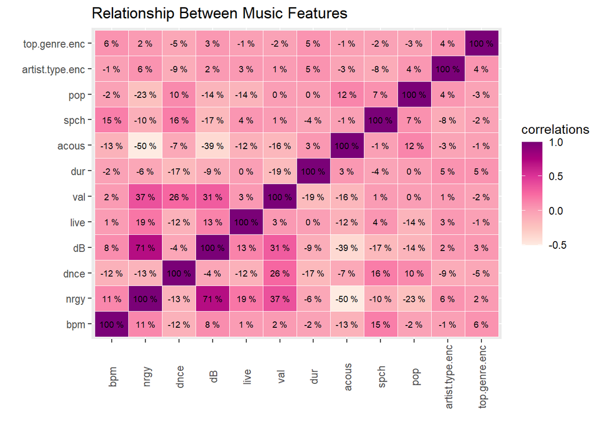

```r
df.subset.song%>%
  cor()%>%
  melt()%>%
  ggplot(aes(Var1, Var2, fill=value))+
  geom_tile(color='white')+
  scale_fill_distiller(palette = 'RdPu',direction = 1)+
  geom_text(aes(label=paste(round(value,2)*100,'%')), size=2.5, color='black')+
  labs(x='',y='',fill='correlations', title='Relationship Between Music Features')+
  theme(axis.text.x = element_text(angle = 90, vjust = .5))
```

#### 4.3.6 Show the Trend of BPM, Energy, Danceability, Live, Value, Acoustic, Speechabilty, Popularity From 2010 to 2019

By using ggplot() we are showing the trend of each variable in the span of 10 years starting from 2010 to 2019

```r
bpm<-bpm_mean%>%
  ggplot(aes((`Group.1`), x))+
  geom_point(color='black')+
  geom_line(group=1, color='blue')+
  theme_bw()+
  scale_x_continuous(breaks = seq(2010,2019,2))+
  labs(title='BPM Average per Year', y='BPM', x='Year')
nrgy<-nrgy_mean%>%
  ggplot(aes((`Group.1`), x))+
  geom_point(color='black')+
  geom_line(group=1, color='green')+
  theme_bw()+
  scale_x_continuous(breaks = seq(2010,2019,2))+
  labs(title='Energy Average per Year', y='nrgy', x='Year')
dnce<-dnce_mean%>%
  ggplot(aes((`Group.1`), x))+
  geom_point(color='black')+
  geom_line(group=1, color='red')+
  theme_bw()+
  scale_x_continuous(breaks = seq(2010,2019,2))+
  labs(title='Danceability Average per Year', y='dnce', x='Year')
live<-live_mean%>%
  ggplot(aes((`Group.1`), x))+
  geom_point(color='black')+
  geom_line(group=1, color='magenta')+
  theme_bw()+
  scale_x_continuous(breaks = seq(2010,2019,2))+
  labs(title='Live Average per Year', y='live', x='Year')
val<-val_mean%>%
  ggplot(aes((`Group.1`), x))+
  geom_point(color='black')+
  geom_line(group=1, color='orange')+
  theme_bw()+
  scale_x_continuous(breaks = seq(2010,2019,2))+
  labs(title='Value Average per Year', y='val', x='Year')
acous<-acous_mean%>%
  ggplot(aes((`Group.1`), x))+
  geom_point(color='black')+
  geom_line(group=1, color='purple')+
  theme_bw()+
  scale_x_continuous(breaks = seq(2010,2019,2))+
  labs(title='Acoustic Average per Year', y='acous', x='Year')
spch<-spch_mean%>%
  ggplot(aes((`Group.1`), x))+
  geom_point(color='black')+
  geom_line(group=1, color='brown')+
  theme_bw()+
  scale_x_continuous(breaks = seq(2010,2019,2))+
  labs(title='Speechability Average per Year', y='spch', x='Year')
pop<-pop_mean%>%
  ggplot(aes((`Group.1`), x))+
  geom_point(color='black')+
  geom_line(group=1, color='navy')+
  theme_bw()+
  scale_x_continuous(breaks = seq(2010,2019,2))+
  labs(title='Popular Average per Year', y='pop', x='Year')
```

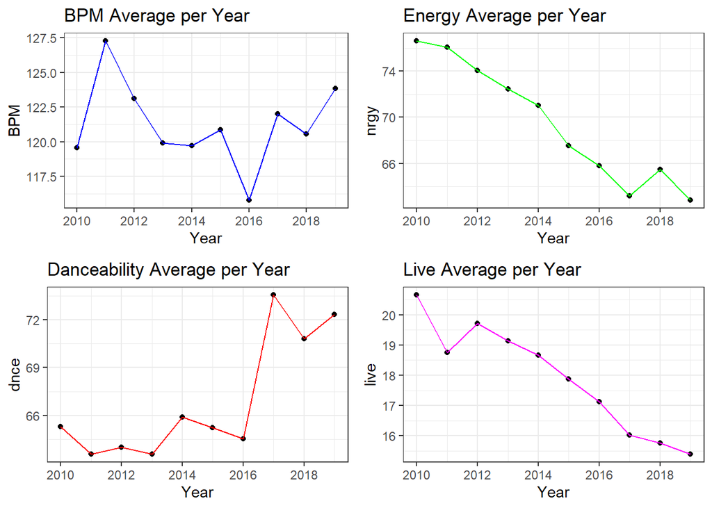

```r
grid.arrange(bpm, nrgy, dnce, live, ncol=2, nrow =2)
```

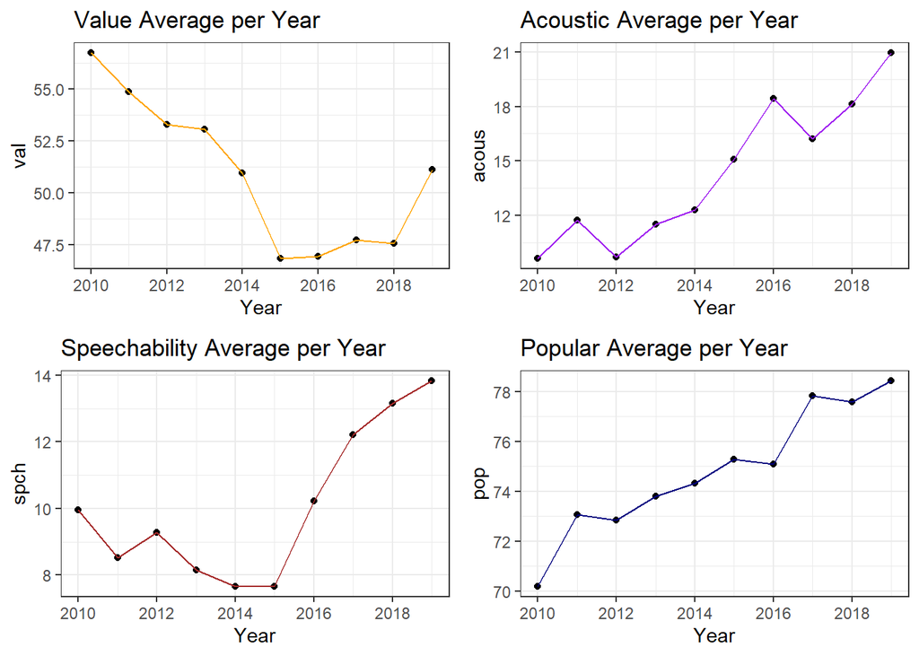

```r
grid.arrange(val, acous, spch, pop, ncol=2, nrow =2)
```

#### 4.3.7 Create Top Genre Model and Get the Best K for The Prediction (Predict Using KNN)

Now we can calculate the proportion of correct classification for k = 26, 27 after building the model according those K value.

```r
ACC.25 <- 100 * sum(test_labels == knn.25)/NROW(test_labels)
ACC.26 <- 100 * sum(test_labels == knn.26)/NROW(test_labels)
ACC.27 <- 100 * sum(test_labels == knn.27)/NROW(test_labels)
sprintf("Accuracy for K-Value 25 : %f",ACC.25)
```

```
## [1] "Accuracy for K-Value 25 : 93.814433"
```

```r
sprintf("Accuracy for K-Value 26 : %f",ACC.26)
```

```
## [1] "Accuracy for K-Value 26 : 93.814433"
```

```r
sprintf("Accuracy for K-Value 27 : %f",ACC.27)
```

```
## [1] "Accuracy for K-Value 27 : 93.814433"
```

We can also get the best k-value for this prediction by using a function that check all of the optimal k by looping until the number of k-value that we desire. In this case let us loop it until k-value 30

```r
i=1
k.optm=1
for (i in 1:30){
  knn.mod <- knn(train=train, test=test, cl=train_labels, k=i)
  k.optm[i] <- 100 * sum(test_labels == knn.mod)/NROW(test_labels)
  k=i
  cat(k,'=',k.optm[i],'\n')
}
```

```
## 1 = 99.65636
## 2 = 99.65636
## 3 = 99.65636
## 4 = 98.96907
## 5 = 98.96907
## 6 = 98.96907
## 7 = 98.96907
## 8 = 98.96907
## 9 = 98.96907
## 10 = 98.96907
## 11 = 98.96907
## 12 = 98.62543
## 13 = 98.62543
## 14 = 98.62543
## 15 = 98.62543
## 16 = 98.28179
## 17 = 96.56357
## 18 = 96.56357
## 19 = 96.56357
## 20 = 96.56357
## 21 = 96.21993
## 22 = 96.21993
## 23 = 94.50172
## 24 = 94.50172
## 25 = 93.81443
## 26 = 93.81443
## 27 = 93.81443
## 28 = 93.81443
## 29 = 93.47079
## 30 = 93.12715
```

## **5. Data Visualization**

We are showing our analysis results in the form of plots and tables using ggplot(), plot(), corrplot(), and kable() functions.

#### 5.1 Get Top Popular Song Genre for Every 5 Year

#### First Five Year

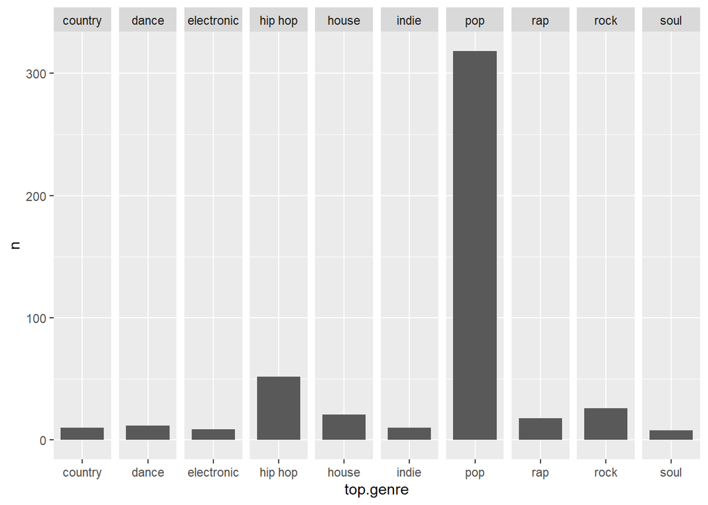

```r
ggplot(data = popular.genre.first, aes(x = top.genre, y = n)) +
  geom_col() +
  facet_grid(.~top.genre, scales = "free_x")
```

#### Second Five Year

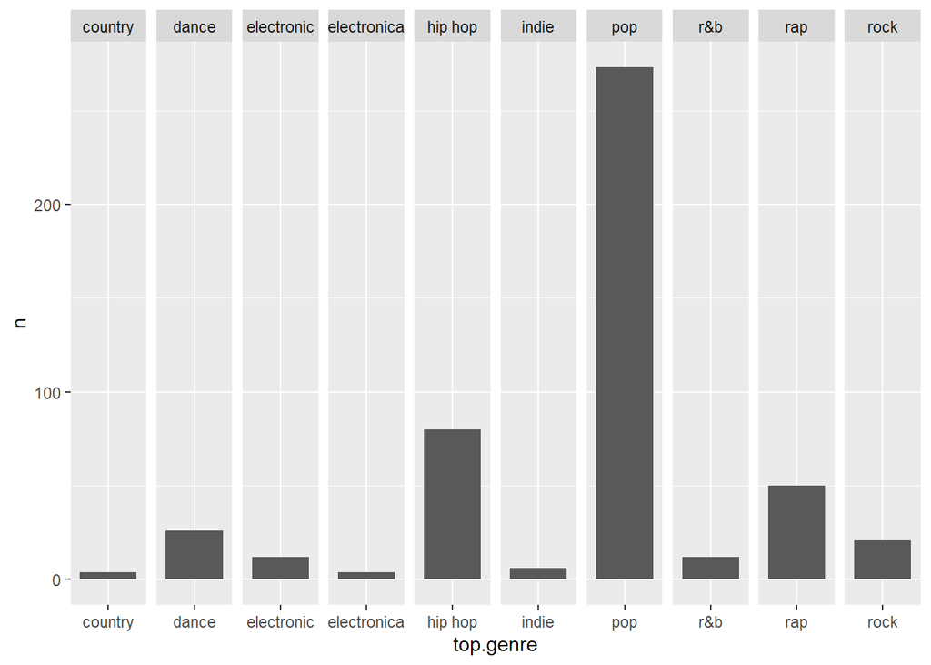

```r
ggplot(data = popular.genre.second, aes(x = top.genre, y = n)) +
  geom_col() +
  facet_grid(.~top.genre, scales = "free_x")
```

#### 5.2 Get Top Popular Artist for Every 5 Year

#### First Five Year

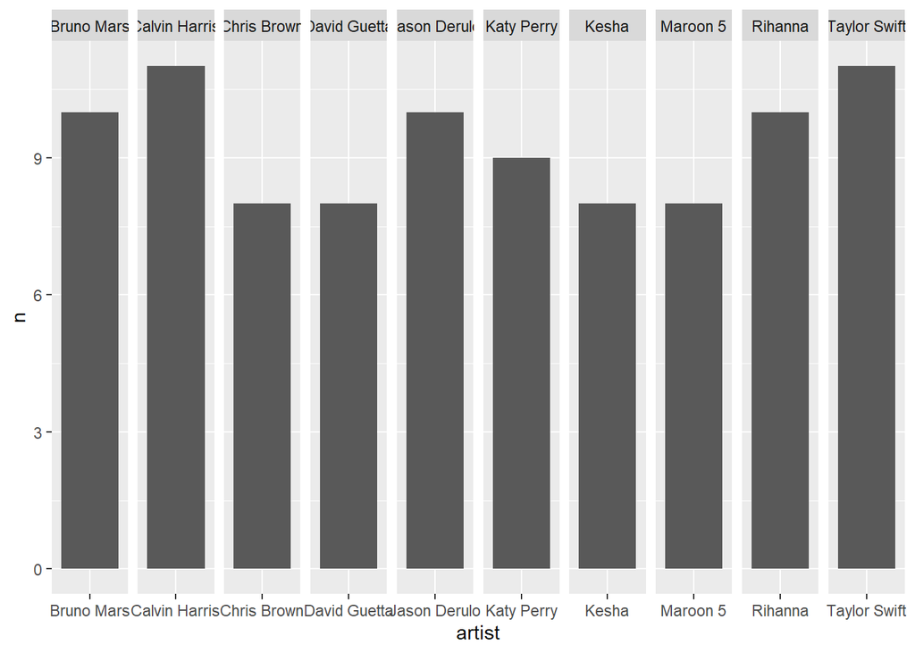

```r
ggplot(data = popular.artist.first, aes(x = artist, y = n)) +
  geom_col() +
  facet_grid(.~artist, scales = "free_x")
```

#### Second Five Year

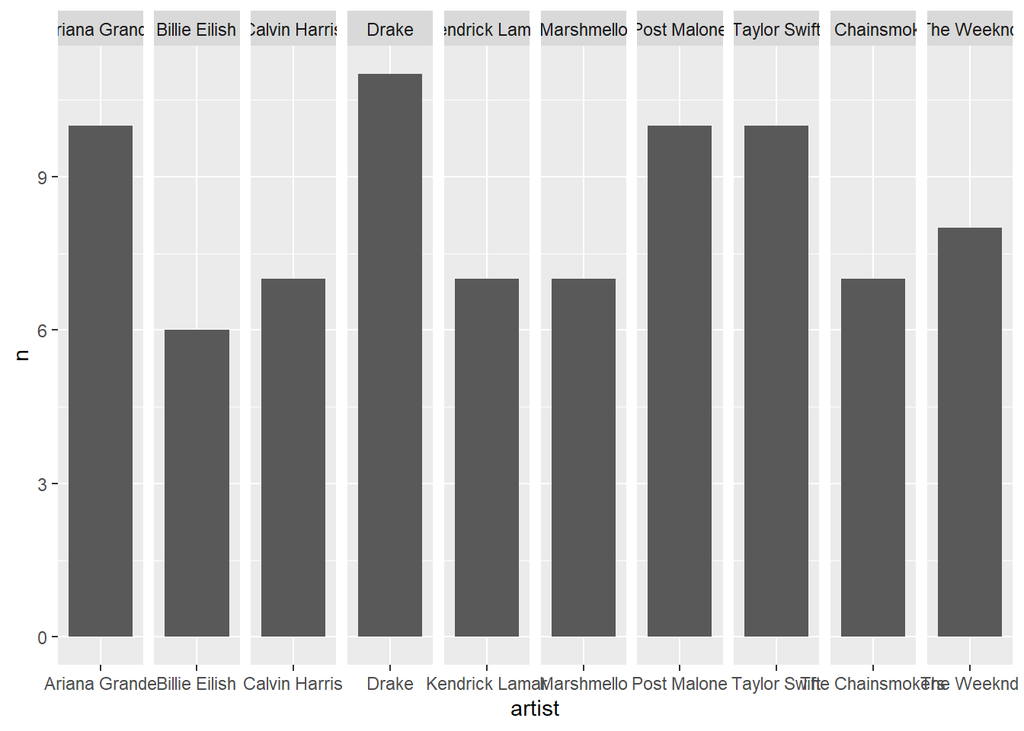

```r
ggplot(data = popular.artist.second, aes(x = artist, y = n)) +
  geom_col() +
  facet_grid(.~artist, scales = "free_x")
```

#### 5.3 Get Songs that Was Released Outside the Chart Year Range

To make it look simple, we will just show several column

```r
df.song.released.outside.subset<-df.song.released.outside[,1:4]
df.song.released.outside.subset$top.year<-df.song.released.outside$top.year
df.song.released.outside.subset$artist.type<-df.song.released.outside$artist.type
row.names(df.song.released.outside.subset)<-1:nrow(df.song.released.outside.subset)
kable(df.song.released.outside.subset, caption = "Song that was released outside the chart year range ")
```

Song that was released outside the chart year range

| title | artist | top.genre | year.released | top.year | artist.type |
| --- | --- | --- | --- | --- | --- |
| STARSTRUKK (feat. Katy Perry) | 3OH!3 | pop | 2009 | 2010 | Duo |
| Imma Be | Black Eyed Peas | pop | 2009 | 2010 | Band/Group |
| Memories (feat. Kid Cudi) | David Guetta | house | 2009 | 2010 | Solo |
| Gettin’ Over You (feat. Fergie & LMFAO) | David Guetta | house | 2009 | 2010 | Solo |
| Replay | Iyaz | pop | 2009 | 2010 | Solo |
| Down | Jay Sean | pop | 2009 | 2010 | Solo |
| Do You Remember | Jay Sean | pop | 2009 | 2010 | Solo |
| Young Forever | JAY-Z | hip hop | 2009 | 2010 | Solo |
| Heartbreak Warfare | John Mayer | pop | 2009 | 2010 | Solo |
| Half of My Heart | John Mayer | pop | 2009 | 2010 | Solo |
| Wavin’ Flag | K’NAAN | reggae | 2009 | 2010 | Solo |
| Live Like We’re Dying | Kris Allen | pop | 2009 | 2010 | Solo |
| Bad Romance | Lady Gaga | pop | 2009 | 2010 | Solo |
| Telephone | Lady Gaga | pop | 2009 | 2010 | Solo |
| Alejandro | Lady Gaga | pop | 2009 | 2010 | Solo |
| Fireflies | Owl City | electronic | 2009 | 2010 | Band/Group |
| Rude Boy | Rihanna | pop | 2009 | 2010 | Solo |
| Hard | Rihanna | pop | 2009 | 2010 | Solo |
| Riverside | Sidney Samson | house | 2009 | 2010 | Solo |
| Carry Out (Featuring Justin Timberlake) | Timbaland | pop | 2009 | 2010 | Solo |
| If We Ever Meet Again (Featuring Katy Perry) | Timbaland | pop | 2009 | 2010 | Solo |
| Say Aah (feat. Fabolous) | Trey Songz | pop | 2009 | 2010 | Solo |
| BedRock | Young Money | pop | 2009 | 2010 | Band/Group |
| Good Life | OneRepublic | pop | 2009 | 2011 | Band/Group |
| Bohemian Rhapsody - Remastered 2011 | Queen | rock | 1975 | 2019 | Band/Group |

#### 5.4 Get Artist which Appeared on the Charts Maximum Number of Times

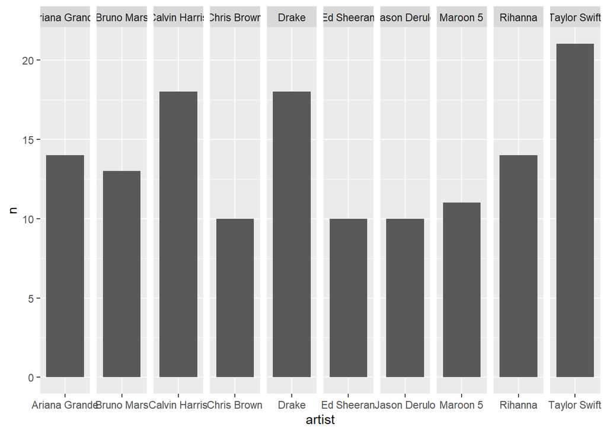

```r
ggplot(data = popular.artist, aes(x = artist, y = n)) +
  geom_col() +
  facet_grid(.~artist, scales = "free_x")
```

#### 5.5 Show the Relationship Between Music Features

For the visualization part, we are going to use some methods that are provided in the corrplot() library, as shown below:

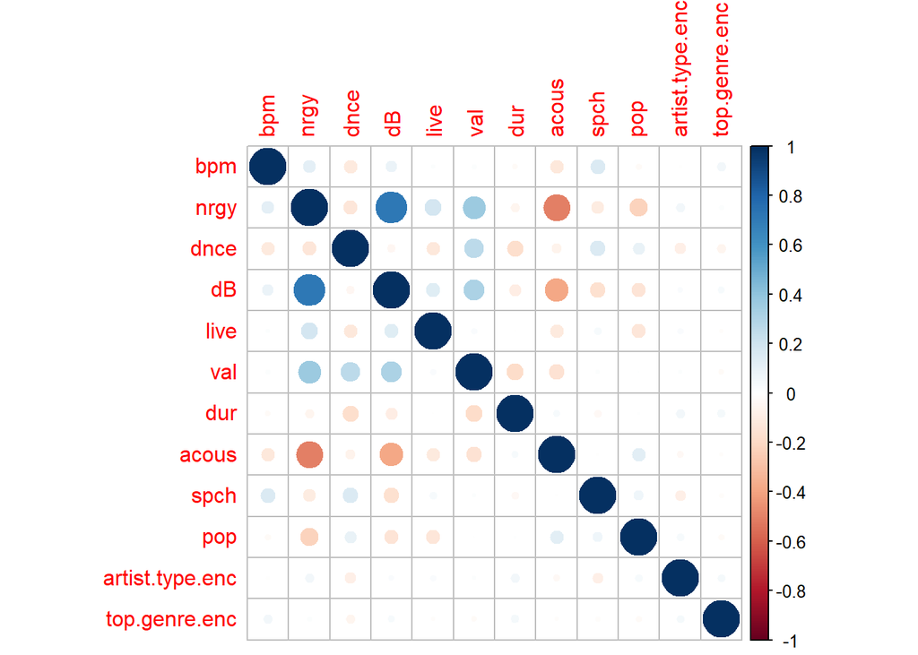

```r
corrplot(corrsong,method = "circle")
```

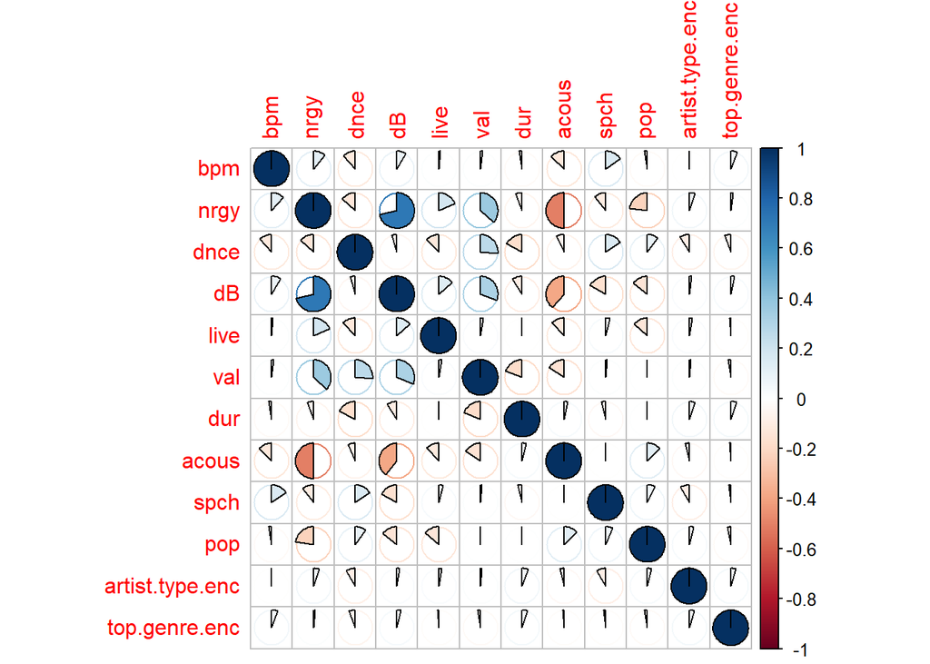

```r
corrplot(corrsong,method = "pie")
```

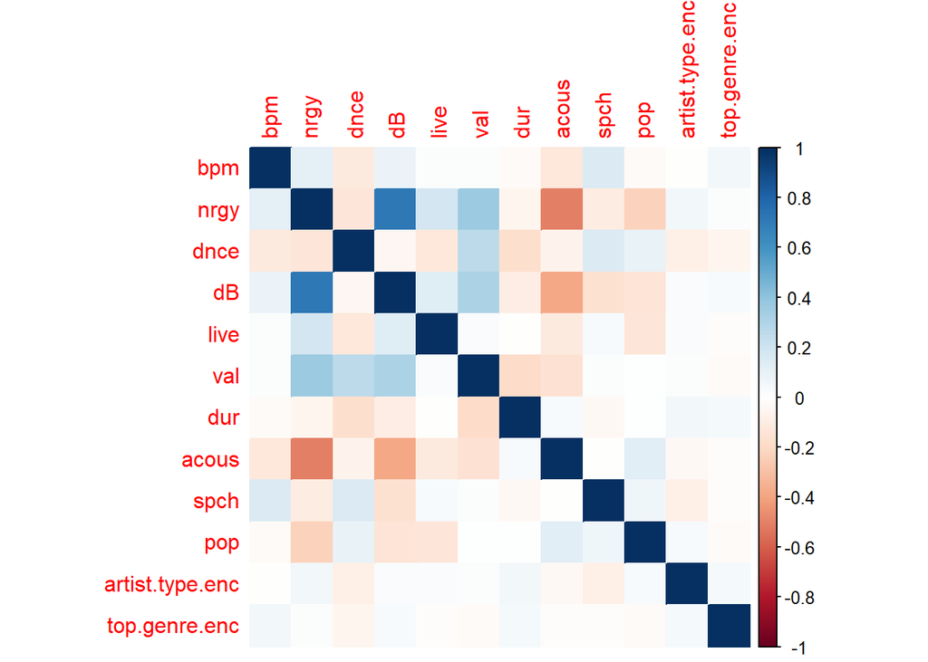

```r
corrplot(corrsong,method = "color")
```

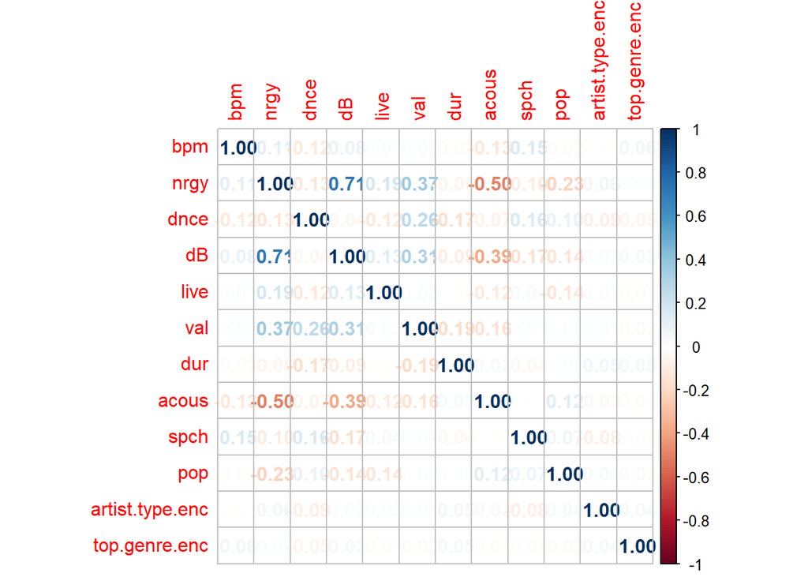

```r
corrplot(corrsong,method = "number")
```

#### 5.6 Show the Trend of BPM, Energy, Danceability, Live, Value, Acoustic, Speechabilty, Popularity From 2010 to 2019

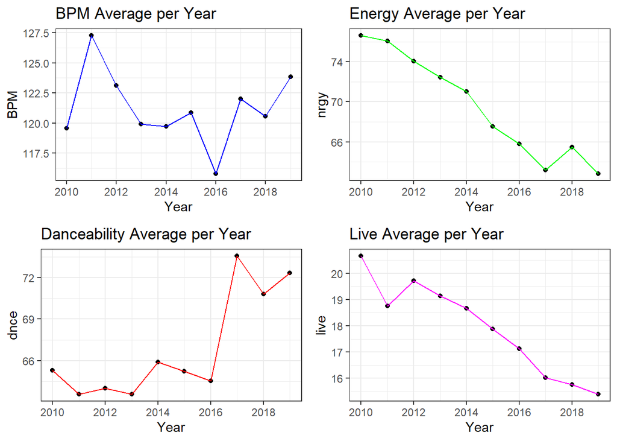

```r
grid.arrange(bpm, nrgy, dnce, live, ncol=2, nrow =2)
```

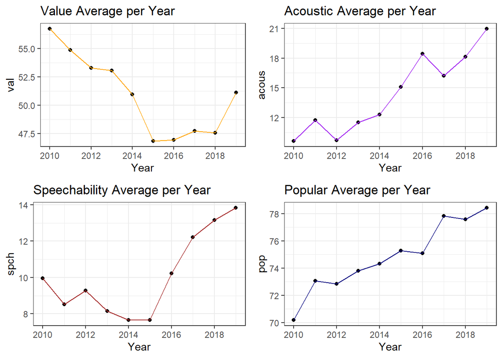

```r
grid.arrange(val, acous, spch, pop, ncol=2, nrow =2)
```

#### 5.7 Create Top Genre Model and Get the Best K for The Prediction (Predict Using KNN)

We can plot the best K-value for the genre prediction

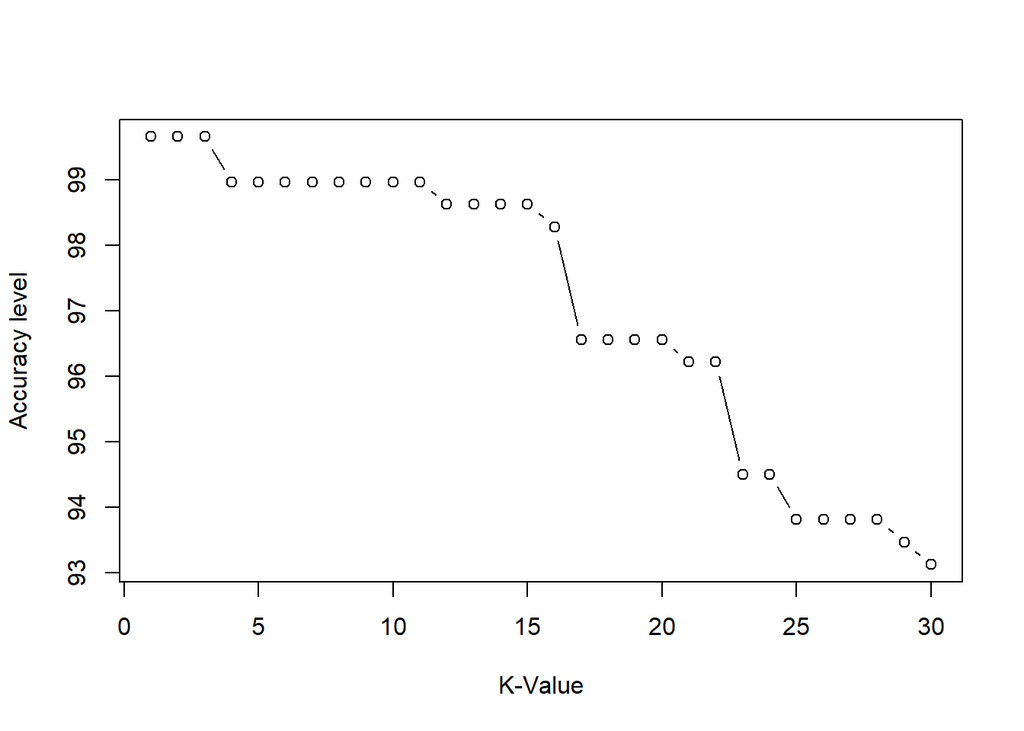

```r
plot(k.optm, type="b", xlab="K-Value",ylab="Accuracy level")
```

## **6. Conclusion**

This project confirms that many things that we can explore and analyze using the provided dataset by Spotify. Althought, at first, we are struggling in using the dataset due to ambiguity in some columns value and class, but we manage to fix that and properly use the dataset in out project

In overall, using R Markdown in this project is quite convenient, because R Markdown facilitate the functionality of R language it self, so it is easier to produce the project report.